# Project1:

# Histgram and Pie chart of different happy moments categores.

Every record in the HappyDB has a predicted sensation category. Those catrgories tagged the memorries so we can have a overview of how the happy moments distribute ampong different categories in differnent memory types.

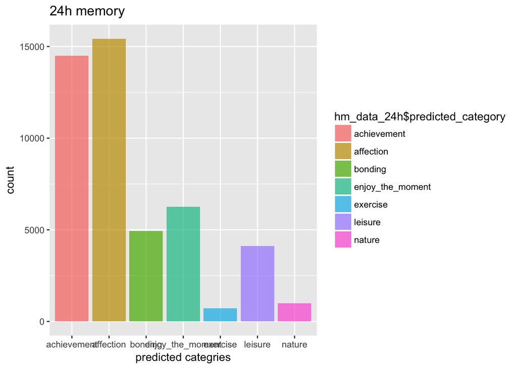

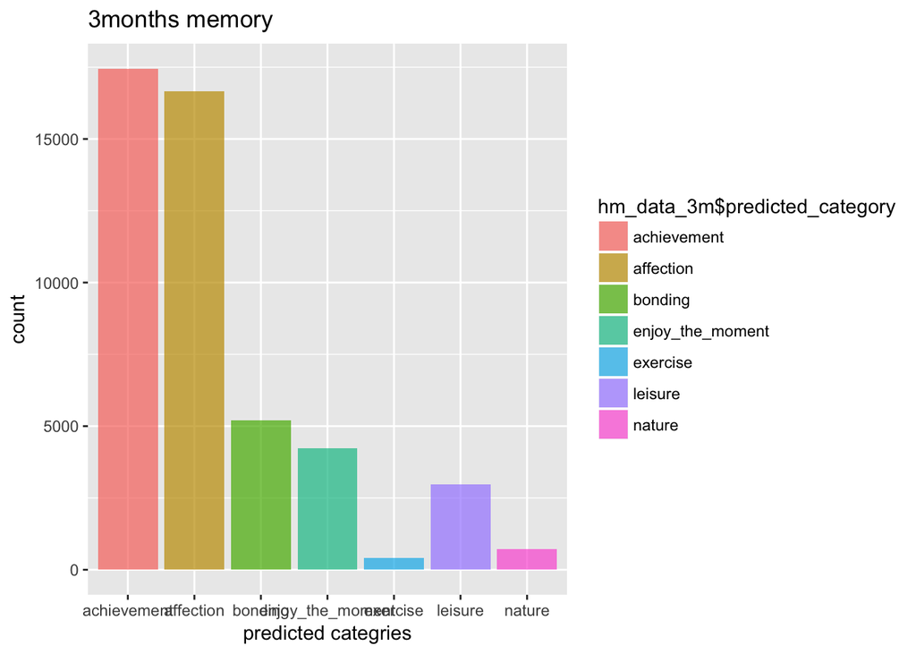

[figure not shown]

[figure not shown]

From the plots we can see that the distribution of happy moments among 7 different categories is slightly different among these two groups. To have a clearer view of the data distribution. We plot a stack histergram of percentage that each group conttrbutes to 7 categories.

# Long term memory VS Short term memory in different categories

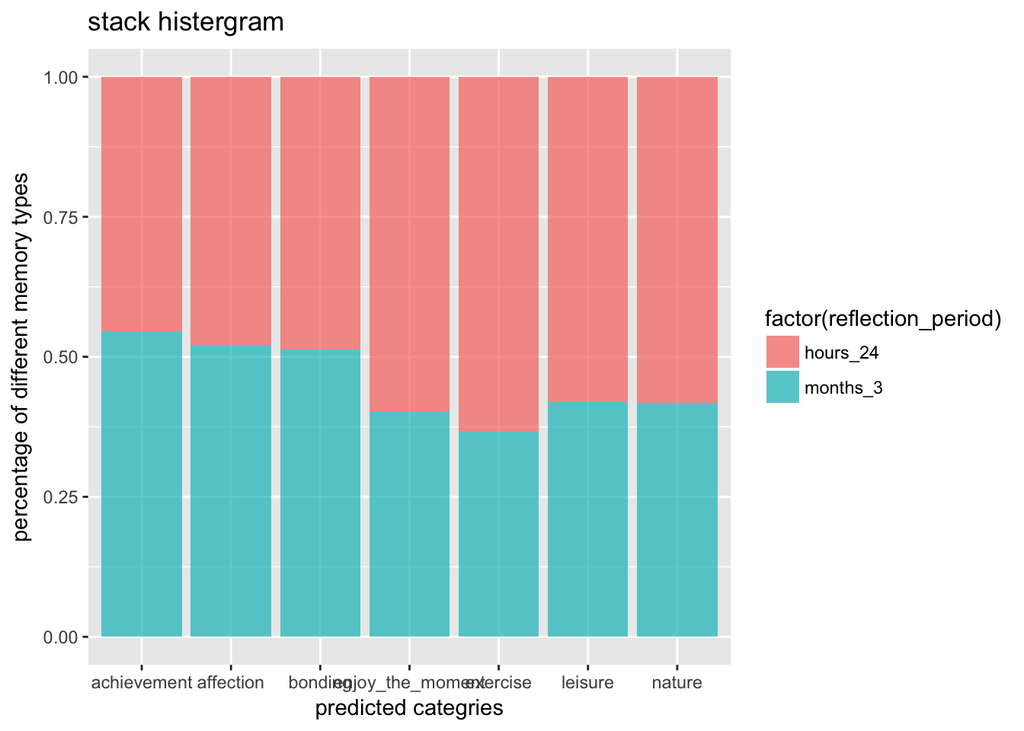

From the plot, we can easily see that long term memory systerm contains more moments of achievement, affection and bonding fellings compared with short term memory. And the happy feelings of “joy the moments”, “exercise”, “leisure” and “nature” are more easily to be stored as short term happy memory.